# A Semi-Supervised Multi-label Classification of news articles on Coronavirus

A Semi-Supervised Multi-label Classification of news articles on Coronavirus 19/05/2020

#### *Team members*

| Name | Email-Id | Mattr No. |
| --- | --- | --- |
| Calida Pereira | calida.pereira@st.ovgu.de | 229945 |
| Chandan Radhakrishna | chandan.radhakrishna@st.ovgu.de | 229746 |
| Nandish Bandi Subbarayappa | nandish.bandi@st.ovgu.de | 229591 |
| Mohit Jaripatke | mohit.jaripatke@st.ovgu.de | 224651 |
| Priyanka Bhargava | priyanka.bhargava@st.ovgu.de | 229675 |

## Background and motivation

Ever since COVID-19 erupted into our world, research institutes and governments have released plenty of databases publicly to allow research groups and independent individuals to analyze the data around the coronavirus’s spread. We are facing an unprecedented public health crisis with the Coronavirus (Covid-19) outbreak. We believe that data-driven decisions, and people working together for the greater good, are one of the better ways to tackle and deal with this difficult time.

In this blog, we are interested to know ‘How the world’s news media is covering the COVID-19 pandemic?’ Building on the massive television news narratives dataset GDELT released a powerful news dataset of the URLs, titles, publication dates and brief snippet of more than 1.1 million worldwide English language online news articles mentioning the virus to enable researchers and journalists to understand the global context of how the outbreak has been covered since November 2019. This dataset has been expanding daily and includes a number of related topics.

A single article on Covid-19 can cover various topics like health, business implications of the disease or climate changes or it could just be a front to propagate fake information. Given the huge amount of news articles floating around the web in the wake of Covid-19, it is very difficult to compile and compare the news articles. To conduct an analysis of what is being discussed during these difficult times, we would have to first collect all the news articles and then annotate them according to their implicit news sub-categories. This motivates us to create an approach such that we could annotate news articles on Coronavirus without any manual intervention. By creating such a pipeline we not only aim to help researchers, media persons and Journalists to have access to similar articles but also avoid the overhead of time spent in reading and understanding unrelated articles. Thus we aim to improve the quality of similar articles and thus topics representing them.

We intend to solve the huge flow of information called “information overload” which makes it harder for users to find similar information on Covid-19 on the internet. We solve this with an application that enables the user to find news of their query/interest effortlessly. We are foreseeing some challenges, that include determining the subtopic, extract only the content of each webpage and present the data to the user. In real-world applications, multi-label classification (MLC) has a lot of utility in which objects can be identified by more than one label. It’s costly and tedious to manually label the dataset. An unsupervised learning approach should, therefore, be considered to take advantage of clustering similar datasets and eventually doing topic modelling to multi-label the clusters. We use unsupervised learning technique(Clustering) to group a collection of articles so that articles in the same category are more similar to each other than those in other groups. Clustering can be used to help classify the types of a structure discovered.

We are trying to analyze the large set of news articles to help make it easier for common people to filter through many articles related to the virus, and find their own resoluteness.Furthermore, we would want to understand the semantic relations between different topics. And finally, analyze keywords to uncover patterns in the news content.

## Project objectives

1. Classification of news articles on Coronavirus(multilabel classification)
2. Comparative analysis of feature extraction methods like word2vec, TD-IDF and BOW.
3. Analysing the semantic relatedness between different articles by Clustering.
4. Topic modelling through LDA to find prevalent keywords representing each topic.
5. Analyzing keywords to uncover patterns in news content.
6. Analyzing different classifiers performance over the dataset.
7. Visualization of insights after classification.

## Dataset

The source of our dataset is from the GDELT Project. GDELT is the largest and comprehensive open database of human society ever created. It has a quarter-billion georeferenced records that represent people, organizations, locations, themes and emotions underlying ongoing events etc. We will be accessing the Coronavirus dataset. This dataset was generated with tags such as “coronavirus” OR “covid-19” OR “corona virus” OR “sars-cov-2”. They have set the start time this early to make it possible to track earlier mentions of other coronaviruses and assess the baseline narrative around them. Collection and accumulation of news websites have been daily done from November 2019 and is still ongoing. The dataset consists of web URL of the news articles on Coronavirus and few other attributes like title and partial new content. We intend to use the web URL’s in the files and scrape all the content from different websites which would then serve as our dataset.

https://www.gdeltproject.org/

By accessing the below URL we’ll be scraping the websites and collecting news content which will serve as our dataset.

http://data.gdeltproject.org/blog/2020-coronavirus-narrative/live_onlinenews/MASTERFILELIST.TXT

## Design overview

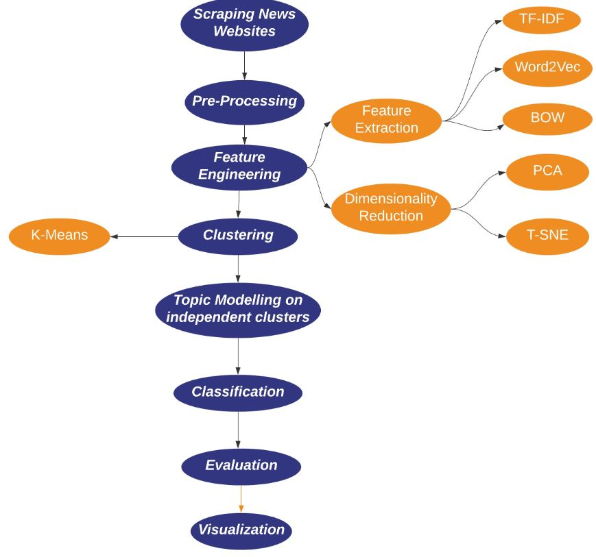

## Project Timeline and Responsibilities

| Task Description | Deadline | **People Responsible** | Reviewed by |
| --- | --- | --- | --- |
| Data Collection and Pre-processing | 29.05.2020 | Priyanka, Calida, Nandish | Mohit, Chandan |
| Feature Engineering | 5.06.2020 | Chandan, Priyanka, Calida | Mohit, Nandish |
| Exploratory Data Analysis and Visualization | 12.06.2020 | Calida, Chandan, Mohit | Priyanka, Nandish |
| Model selection and Hyperparameters tuning | 19.06.2020 | Nandish, Priyanka, Calida | Chandan, Mohit |
| Predictive Modelling and Model Evaluation | 26.06.2020 | Mohit, Chandan, Nandish | Priyanka, Calida |
| Adhoc issues and Testing | 29.06.2020 | All |  |
| Visualization and Website Content | 3.07.2020 | All |  |